# Multiple testing

October 21, 2015

## Three eras of statistics

**The age of Quetelet and his successors, in which huge census-level data sets were brought to bear on simple but important questions**: Are there more male than female births? Is the rate of insanity rising?

The classical period of Pearson, Fisher, Neyman, Hotelling, and their successors, intellectual giants who **developed a theory of optimal inference capable of wringing every drop of information out of a scientific experiment**. The questions dealt with still tended to be simple Is treatment A better than treatment B?

**The era of scientific mass production**, in which new technologies typified by the microarray allow a single team of scientists to produce data sets of a size Quetelet would envy. But now the flood of data is accompanied by a deluge of questions, perhaps thousands of estimates or hypothesis tests that the statistician is charged with answering together; not at all what the classical masters had in mind. Which variables matter among the thousands measured? How do you relate unrelated information?

http://www-stat.stanford.edu/~ckirby/brad/papers/2010LSIexcerpt.pdf

## Why I am the one true heir of multiple testing

[figure not shown]

## Reasons for multiple testing

[figure not shown]

## Why correct for multiple tests?

[figure not shown]

http://xkcd.com/882/

## Why correct for multiple tests?

[figure not shown]

http://xkcd.com/882/

## The most widely used statistic

[figure not shown]

## Haters gonna hate

[figure not shown]

## P-values

[figure not shown]

http://varianceexplained.org/statistics/interpreting-pvalue-histogram/

## P-values - signal

[figure not shown]

http://varianceexplained.org/statistics/interpreting-pvalue-histogram/

## P-values - noise

[figure not shown]

http://varianceexplained.org/statistics/interpreting-pvalue-histogram/

## P-values - two groups

[figure not shown]

http://varianceexplained.org/statistics/interpreting-pvalue-histogram/

## P-values - two groups

[figure not shown]

http://varianceexplained.org/statistics/interpreting-pvalue-histogram/

## Types of errors

Suppose you are testing a hypothesis that a parameter \(\beta\) equals zero versus the alternative that it does not equal zero. These are the possible outcomes.

[figure not shown]

**Type I error or false positive (\(V\))** Say that the parameter does not equal zero when it does

**Type II error or false negative (\(T\))** Say that the parameter equals zero when it doesn't

## Error rates

[figure not shown]

## Interpretation

[figure not shown]

## Order p-values and draw a cutoff

[figure not shown]

## Bonferroni

[figure not shown]

## Bonferroni adjusted p-values

\[ p^{bon}_i = \inf\{\alpha : p \in S_{\alpha}^{bon}\}\] \[ = \inf\{\alpha : p_i \leq \alpha/m\}\] \[ = \min\{m p_i,1\}\]

The adjusted p-value is no longer uniform under the null, but the adjusted p-value is attractive, because of the interpretation that \(p_i^{bon} \leq \alpha\) implies that FWER \(\leq \alpha\). See `p.adjust` in R.

## Bonferroni and dependence

In the extreme case; all tests have almost the same \(p_j\); if one is small, they're all small. so:

\[ P ({\rm any\; null\;} p_i < \alpha/m) \approx m_0/m P(p_1 < \alpha/m)\] \[ = (m_0/m) (\alpha/m)\] \[ \approx \alpha/m\]

but using \(p_i < \alpha\) would have been better. For positively dependent test statistics increasing correlation \(\Rightarrow\) more conservative results on average. But we can get catastrophic errors.

Suppose \(p_i\) are all identical for the null cases and by chance \(p_i < \alpha/m\). How many errors?

## The Bonferroni Correction Control the FWER

Suppose there are \(m\) tests and the data for the first \(m_0\) tests follows the null distribution then: \[ P(\{ {\rm \# \; of \; false \; positives} \geq 1\}) = P\left(\sum_{i=1}^{m_0} I(p_i \leq \alpha/m) > 0\right)\] \[ = P\left(\bigcup_{i=1}^{m_0} \{p_i \leq \alpha/m\}\right)\] \[ \leq \sum_{i=1}^{m_0} P(p_i \leq \alpha/m)\] \[ \leq \frac{m_0}{m} \alpha \leq \alpha \]

## A common application of Bonferroni

"A genome-wide association study identifies three loci associated with susceptibility to uterine fibroids"

For each of \(\sim 1\times10^7\) SNPs with data \(X_i\) fit the model: \[ {\rm logit}(P(Y_j = 1 | X_ij)) = \beta_{0i} + \beta_{1i} X_{ij}\]

[figure not shown]

## False discovery rates

A less conservative measure of (hypothetical) embarrassment \[\frac{V}{R\vee1} = \frac{\#{\rm false \; positives}}{\#{\rm declared \; positives}}\]

- This is the **realized** False Discovery Rate
- "Badness" of each Type I error depends on \(R\)
- \(R \vee 1\) stops \(0/0\), sets embarrassment = 0 when \(R = 0\)
- For a given decision rule, define its \(FDR = E\left[\frac{V}{R\vee 1}\right]\)

This is the most popular correction when performing *lots* of tests say in genomics, imagining, astronomy, or other signal-processing disciplines.

## Benjamini-Hochberg

[figure not shown]

## An example

[figure not shown]

## Storey's approach - less conservative than BH

\[FDR \approx \frac{E[false \; postives]}{E[total \; positives]}\]

We could estimate these quantites by:

\[ E[false \; postives] \approx \pi_0 \times m \times t\] \[ E[total \; positives] \approx R(t)\]

Then \[FDR \approx \frac{\pi_0 \times m \times t}{R(t)}\]

Leading to a cutoff of \[ \frac{\alpha \times i}{\pi_0 \times m}\]

## Estimating \(\pi_0\)

[figure not shown]

## Case study I: no true positives

```r
set.seed(1010093)
pValues <- rep(NA,1000)
for(i in 1:1000){
  y <- rnorm(20)
  x <- rnorm(20)
  pValues[i] <- summary(lm(y ~ x))$coeff[2,4]
}

# Controls false positive rate
sum(pValues < 0.05)
```

```
## [1] 51
```

## Case study I: no true positives

```r
# Controls FWER
sum(p.adjust(pValues,method="bonferroni") < 0.05)
```

```
## [1] 0
```

```r
# Controls FDR
sum(p.adjust(pValues,method="BH") < 0.05)
```

```
## [1] 0
```

## Case study II: 50% true positives

```r
set.seed(1010093)
pValues <- rep(NA,1000)
for(i in 1:1000){
  x <- rnorm(20)
  # First 500 beta=0, last 500 beta=2
  if(i <= 500){y <- rnorm(20)}else{ y <- rnorm(20,mean=2*x)}
  pValues[i] <- summary(lm(y ~ x))$coeff[2,4]
}
trueStatus <- rep(c("zero","not zero"),each=500)
table(pValues < 0.05, trueStatus)
```

```
##        trueStatus
##         not zero zero
##   FALSE        0  476
##   TRUE       500   24
```

## Case study II: 50% true positives

```r
# Controls FWER
table(p.adjust(pValues,method="bonferroni") < 0.05,trueStatus)
```

```
##        trueStatus
##         not zero zero
##   FALSE       23  500
##   TRUE       477    0
```

```r
# Controls FDR
table(p.adjust(pValues,method="BH") < 0.05,trueStatus)
```

```
##        trueStatus
##         not zero zero
##   FALSE        0  487
##   TRUE       500   13
```

## Case study II: 50% true positives

**P-values versus adjusted P-values**

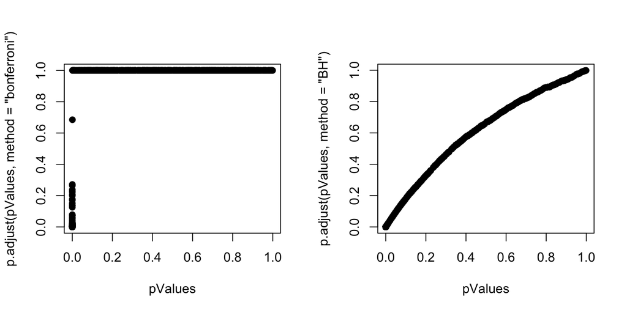

```r
par(mfrow=c(1,2))
plot(pValues,p.adjust(pValues,method="bonferroni"),pch=19)
plot(pValues,p.adjust(pValues,method="BH"),pch=19)
```

## Researcher degrees of freedom

[figure not shown]

## One of the hottest areas of debate

Fisher (JASA, 1943): "It is not my purpose to make Dr. Berkson seem ridiculous, nor, of course, to prevent him from providing innocent amusement. Had he looked up Hersh’s original paper he would have been spared a blunder,…"

Berkson (Biometrics, 1954): "I consented to comment on the remarks of Sir Ronald Fisher only with considerable reluctance. The passages of his article that have to do with my work are so far out of the bounds of reasonableness or relevancey that on ﬁrst reading them I could only believe that he had heen misinformed regarding my statement"

http://people.stat.sfu.ca/~lockhart/richard/Talks/UBC_SFU.pdf

## One of the hottest areas of debate

Fisher (Biometrics,1954): "It is a great pity that Cochran in this paper does not clearly point out that such adjustments have no useful function, at least ﬁnally, if it is intended to perform a correct analysis. The subsequent papers (5, 6) by Bartlett (1947) and Anscombe (1948)) show no such consciousness of the situation as they would have obtained had Cochran expressed himself more deﬁnitely."

"It is unfortunate that Bartlett did not restate his own views on this topic without making misleading allusions to mine."

Fisher (JRSS-B, 1957): "If Professor Neyman were in the habit of learning from others he might proﬁt from…"

## One of the hottest areas of debate

Neyman (1951) "In particular, three major concepts were introduced by Fisher and consistently propagandized by him in a number of publications. These are mathematical likelihood as a measure of the conﬁdence in a hypothesis, suﬃcient statistics, and ﬁducial probability. Unfortunately, in conceptual mathematical statistics Fisher was much less successful than in manipulatory, and of the three above concepts only one, that of a suﬃcient statistic, continues to be of substantial interest. The other two proved to be either futile or self-contradictory and have been more or less generally abandoned."

## One of the hottest areas of debate

Pearson in another review: "Most readers will regret the inclusion of the Note on Paper (29,1937) which, if nothing more, shows in its last sentences, a profound ignorance of Karl Pearson’s character and, indeed, of his contemporaries."

## More recently

Ioannidis: "A reproducibility check of the raw data shows that much of the data Jager and Leek used are either wrong or make no sense: most of the usable data were missed by their script, 94% of the abstracts that reported ≥2 P-values had high correlation/overlap between reported outcomes, and only a minority of P-values corresponded to relevant primary outcomes. The Jager and Leek paper exemplifies the dreadful combination of using automated scripts with wrong methods and unreliable data. Sadly, this combination is common in the medical literature."

Gelman and O'Rourke: "We think what Jager and Leek are trying to do is hopeless, at least if applied outside a very narrow range of randomized clinical trials with prechosen endpoints"

Talking about our paper [An estimate of the science-wise false discovery rate and application to the top medical literature](http://biostatistics.oxfordjournals.org/content/15/1/1)